# The Helium Atom

Chem 3240 · Lecture 7.1

Davit Potoyan

## Why Helium Is Hard

- **Two electrons**, one nucleus with $Z = 2$.
- Hydrogen has an **exact** solution.
- Helium has **no closed-form** solution.
- The culprit: **electron, electron repulsion**.

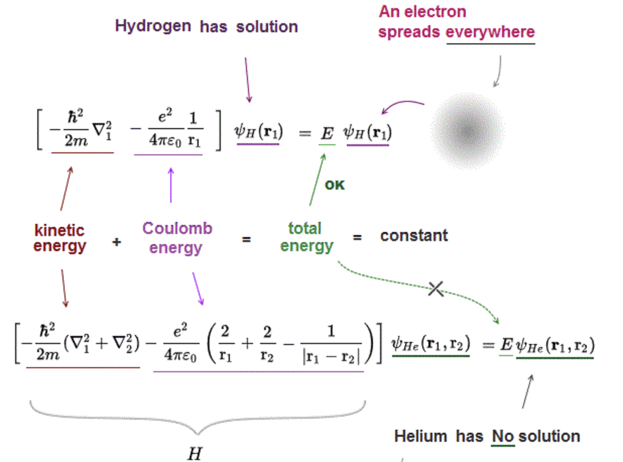

## The Helium Hamiltonian

$$\hat{H} = -\frac{\hbar^2}{2m_e}\left(\Delta_1 + \Delta_2\right) - \frac{1}{4\pi\epsilon_0}\left(\frac{Ze^2}{r_1} + \frac{Ze^2}{r_2} - \frac{e^2}{r_{12}}\right)$$

- **Kinetic** energy of both electrons.
- **Attraction** to the nucleus.
- The **tough term** $-\,e^2/r_{12}$ couples the coordinates.

## The Term That Breaks Everything

- Repulsion $e^2/r_{12}$ **ties the two electrons together**.
- The Hamiltonian **no longer separates** into one-electron pieces.
- Without it, helium would just be **two hydrogen atoms**.
- Strategy: **drop it first**, then patch it back.

## The Independent-Electron Approximation

- **Ignore** the $r_{12}$ term.

$$\hat{H} = \hat{H}_1 + \hat{H}_2$$

$$\hat{H}_i = -\frac{\hbar^2}{2m_e}\Delta_i - \frac{Ze^2}{4\pi\epsilon_0 r_i}$$

- A **sum** of two hydrogenlike atoms, so the problem **separates**.

## The Separable Solution

$$E = E_1 + E_2 = -RZ^2\left(\frac{1}{n_1^2} + \frac{1}{n_2^2}\right)$$

$$\psi(r_1,r_2) = \frac{1}{\pi}\left(\frac{Z}{a_0}\right)^3 e^{-Z(r_1 + r_2)/a_0}$$

- Ground state: both electrons in $1s$, so $\psi = 1s(1)\,1s(2)$.

## A Better Trial: Vary the Charge

- Treat the nuclear charge $Z$ as an **adjustable parameter**.

$$E = \langle\psi|\hat{H}|\psi\rangle = \left[Z^2 - \frac{27Z}{8}\right]\frac{e^2}{4\pi\epsilon_0 a_0}$$

- The **variational principle**: lower energy means a **better** wavefunction.

## Minimize the Energy

- Set the derivative to zero:

$$\frac{dE}{dZ} = \left(2Z - \frac{27}{8}\right)\frac{e^2}{4\pi\epsilon_0 a_0} = 0$$

$$Z = \frac{27}{16} \approx 1.7, \qquad E \approx -77.5 \text{ eV}$$

- Closer to the exact $-79.0$ eV than $Z = 2$ gave.

## Shielding

- The optimal charge $Z \approx 1.7$ is **less than** the true $Z = 2$.
- Each electron **screens** the nucleus from the other.
- The other electron feels a **reduced effective charge**.
- Our **first quantitative encounter** with shielding.

## The Lesson of Helium

- Even **two electrons** have no closed-form solution.
- Build wavefunctions from **hydrogenlike orbitals**.
- Use the **variational principle** to systematically improve them.
- **Perturbation theory** offers an alternative route.

# Takeaway

> Helium has no exact solution because the $1/r_{12}$ repulsion couples the electrons. We approximate it as **two hydrogenlike orbitals**, then sharpen the estimate with the **variational principle**: optimizing the nuclear charge gives $Z \approx 1.7$, our first measure of **shielding**, and an energy of $-77.5$ eV against the exact $-79.0$ eV.